# Pipeline klasyfikatora gestów dłoni

**Autorzy:** Maciej Bik, Kamil Buszta, Wiktor Cioch, Arkadiusz Cios

Klasyfikator **SVM** (Support Vector Machine) rozpoznaje 10 gestów dłoni. SVM jest modelem matematycznym, który szuka hiperpłaszczyzny rozdzielającej klasy w przestrzeni wielowymiarowej - nie przetworzy bezpośrednio surowego zdjęcia. Potrzebuje **wektora liczb o stałej, identycznej długości** dla każdego przykładu.

Pipeline preprocesingu przekształca dowolne zdjęcie dłoni w znormalizowany wektor **12 288 wartości**. Każda z tych wartości opisuje jeden fragment informacji wizualnej: czy w tym miejscu jest skóra, czy jest krawędź, jak wygląda gradient.

Każde zdjęcie przechodzi przez 9 kroków. Na końcu trzy mapy 64×64 px są ułożone jako kanały tensora i spłaszczane do wektora wejściowego SVM.

[figure not shown]

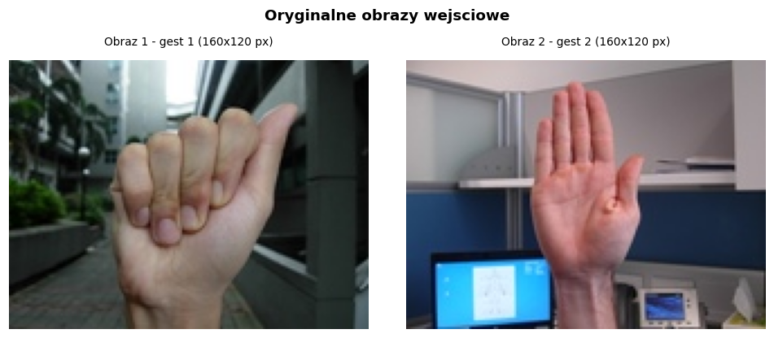

## Krok 0 - Skalowanie do 64×64 px

**Dlaczego?** SVM szuka granicy decyzyjnej w przestrzeni o ustalonej liczbie wymiarów - jeśli jeden obraz ma wektor 10 000 elementów, a inny 25 000, nie da się ich porównać ani nauczyć jednego modelu. Wszystkie obrazy muszą mieć dokładnie taki sam rozmiar wektora. Rozmiar 64×64 to wynik kompromisu: wystarczająco mały, żeby trenowanie SVM na tysiącach obrazów było szybkie, wystarczająco duży, żeby zachować kształt palców i wcięcia między nimi - kluczowe cechy rozróżniające gesty.

**Jak działa?** Interpolacja dwuliniowa - każdy nowy piksel jest ważoną średnią czterech sąsiednich pikseli z oryginalnego obrazu. Zapewnia płynne przeskalowanie bez schodkowatości.

**Wejście:** dowolny rozmiar, 3 kanały BGR, uint8, wartości 0–255

**Wyjście:** 64×64 px, 3 kanały BGR, uint8, wartości 0–255

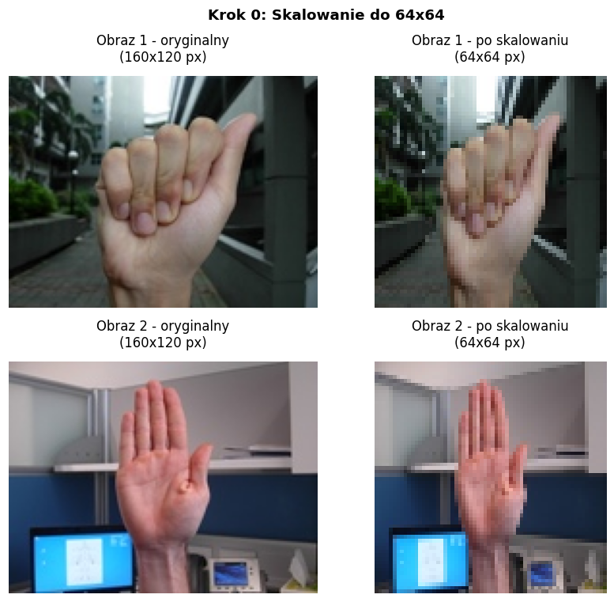

## Krok 1 - F1: Skala szarości

**Dlaczego?** Ten sam gest wykonany przez osobę o ciemnej i jasnej karnacji powinien dawać te same cechy - kolor skóry nie niesie informacji o kształcie. Poza tym obraz kolorowy ma trzy kanały, a operacje Canny i HOG działają na jednym kanale szarości. Skala szarości upraszcza dane bez utraty informacji o geometrii.

Dodatkowy efekt: piksel RGB zmienia wszystkie trzy wartości przy zmianie oświetlenia, natomiast gradient jasności (zmiana wartości między sąsiednimi pikselami) jest dużo bardziej stabilny. Dalsze operacje (Canny, HOG) bazują właśnie na gradientach - więc szarość to właściwe wejście.

**Jak działa?** Trzy kanały BGR łączone są ważoną sumą: Y = 0.114·B + 0.587·G + 0.299·R. Wagi odzwierciedlają czułość ludzkiego oka - zielony wydaje nam się najjaśniejszy.

**Wejście:** 64×64, 3 kanały BGR, uint8, 0–255

**Wyjście:** 64×64, **1 kanał**, uint8, zakres **0–255**

- 0 = czarny (ciemny obszar)
- 255 = biały (jasny obszar)
- wartości pośrednie = odcienie szarości

> F1 jest wejściem do Canny i HOG. **Nie wchodzi** bezpośrednio do tensoru dla SVM.

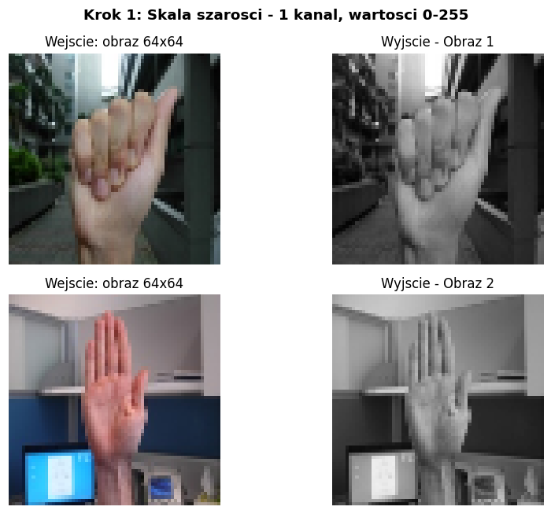

## Krok 2 - Maska koloru skóry

**Dlaczego?** Tło obrazu zawiera masę zbędnych informacji - meble, ściany, ubrania - które generują krawędzie i gradienty niezwiązane z gestem. Zamiast analizować cały obraz, chcemy skupić się wyłącznie na obszarze dłoni. Kolor skóry to naturalna wskazówka, gdzie dłoń się znajduje.

Przestrzeń HSV zamiast RGB, bo w RGB ten sam kolor skóry wygląda zupełnie różnie w zależności od oświetlenia - ciemne pomieszczenie zmienia wartości R, G, B znacząco. W HSV kanał **H (odcień)** koduje kolor niezależnie od jasności. Skóra zawsze mieści się w zakresie H=0–17 (odcienie ciepłe, pomarańczowo-żółte), niezależnie od tego czy jest jaśniej czy ciemniej.

**Jak działa?** Konwersja BGR→HSV, następnie funkcja cv2.inRange zaznacza piksel jako skórę gdy: H∈[0,17] (ciepłe odcienie), S∈[15,170] (wyklucza biel i bardzo intensywne kolory), V∈[0,255] (dowolna jasność).

**Wejście:** 64×64, 3 kanały BGR, uint8, 0–255

**Wyjście:** 64×64, **1 kanał**, uint8, **wyłącznie wartości 0 lub 255** - maska binarna

- 255 = ten piksel wygląda jak skóra
- 0 = ten piksel nie wygląda jak skóra
- **nie ma wartości pośrednich**

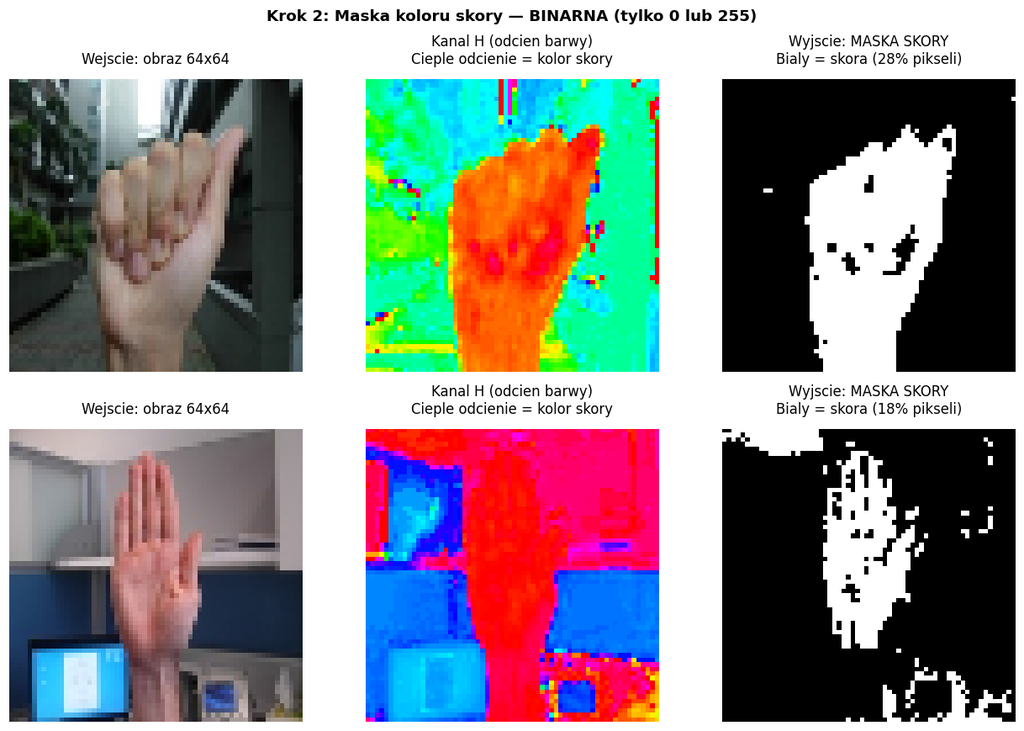

## Krok 3 - Mapa saliencji

**Dlaczego?** Maska skóry ma jeden poważny problem: beżowe ściany, drewniane biurka, czy inne części ciała mogą mieć podobną barwę do skóry i zostać błędnie zaznaczone. Potrzebujemy drugiego, niezależnego kryterium potwierdzającego, że coś jest dłonią.

**Jak działa?** Algorytm StaticSaliencyFineGrained analizuje lokalne kontrasty kolorystyczne i jasności w całym obrazie w przestrzeni częstotliwości. Każdy piksel dostaje wartość proporcjonalną do tego, jak bardzo różni się od otoczenia. Wynik float32 z zakresu 0.0–1.0 jest skalowany do 0–255.

**Wejście:** 64×64, 3 kanały BGR, uint8, 0–255

**Wyjście:** 64×64, **1 kanał**, uint8, zakres **0–255 z wartościami pośrednimi** - skala szarości

- 255 = obszar bardzo wyróżniający się
- 0 = obszar monotonny, zlewa się z otoczeniem
- wartości pośrednie (np. 80, 150, 200) = stopniowe wyróżnienie

[figure not shown]

## Krok 4 - Krawędzie Canny'ego

**Dlaczego?** Kształt gestu jest zakodowany przede wszystkim w konturze dłoni - ile palców widać, jak są rozłożone, czy są złączone czy rozstawione. Krawędzie bezpośrednio opisują te kontury. Są też odporne na zmianę jasności: przesuniecie oświetlenia nie tworzy nowych krawędzi ani nie usuwa istniejących - ważne są zmiany jasności, a nie jej absolutna wartość.

Podwójne progowanie (50/150) usuwa szum przy jednoczesnym zachowaniu prawdziwych krawędzi: krawędź musi być albo wystarczająco silna (>150), albo sąsiadować z silną krawędzią. Dzięki temu losowy szum pikseli nie generuje fałszywych krawędzi.

**Jak działa?** Rozmycie Gaussem (usunięcie szumu), gradienty Sobela (siła i kierunek zmiany jasności), Non-Maximum Suppression (cienkie jednopiksele krawędzie), progowanie z histerezą - próg dolny 50, próg górny 150.

**Wejście:** F1 - 64×64, 1 kanał, szarość 0–255

**Wyjście:** 64×64, **1 kanał**, uint8, **wyłącznie wartości 0 lub 255** - maska binarna

- 255 = wykryto krawędź w tym pikselu
- 0 = brak krawędzi
- **nie ma wartości pośrednich**

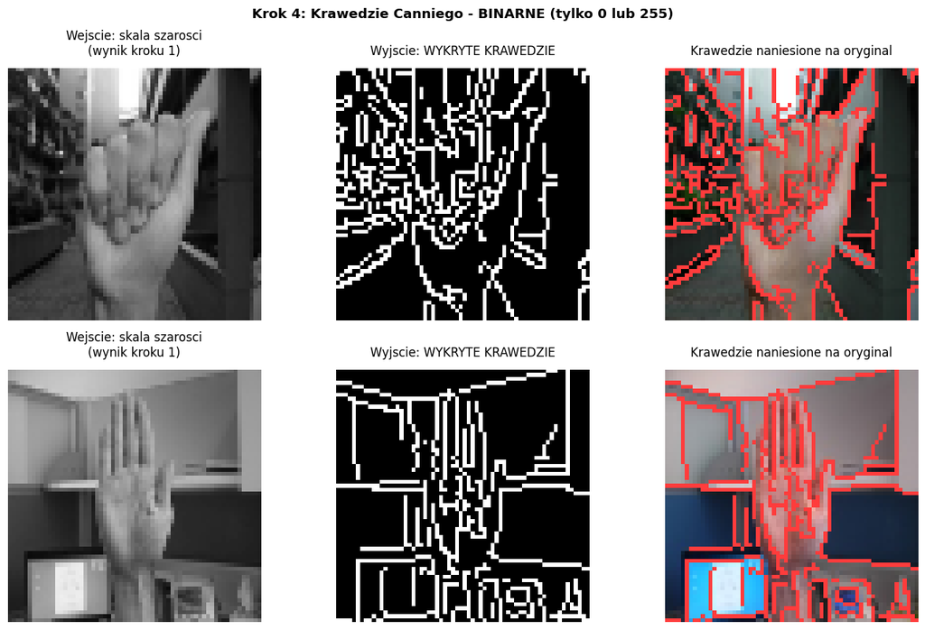

## Krok 5 - Wizualizacja HOG (Histogram of Oriented Gradients)

**Dlaczego?** Canny daje binarne informacje - krawędź jest albo jej nie ma. Traci przy tym dwie ważne informacje: jak silna jest ta krawędź i w jakim kierunku biegnie. HOG te informacje zachowuje.

Dla rozpoznawania gestów kierunek gradientu jest istotny: wyciągnięty palec pionowy tworzy głównie gradienty poziome (po bokach palca), a palec poziomy - głównie gradienty pionowe. Canny nie rozróżni tych dwóch przypadków jeśli kontur jest podobnie długi, ale HOG - tak. Normalizacja bloków 2×2 w HOG sprawia też, że cechy są odporne na małe przesunięcia dłoni w kadrze.

**Jak działa?** Obraz dzielony jest na komórki 8×8 pikseli. W każdej komórce obliczany jest histogram kierunków gradientów w 9 kubełkach (co 20°, od 0° do 180°). Wynik normalizowany w blokach 2×2 komórek i wizualizowany jako obraz: jasność piksela = siła gradientu w tym miejscu.

**Wejście:** F1 - 64×64, 1 kanał, szarość 0–255

**Wyjście:** 64×64, **1 kanał**, uint8, zakres **0–255 z wartościami pośrednimi** - skala szarości

- 255 = silny, wyraźny gradient
- 0 = brak gradientu, jednolity obszar
- wartości pośrednie = różna siła gradientu

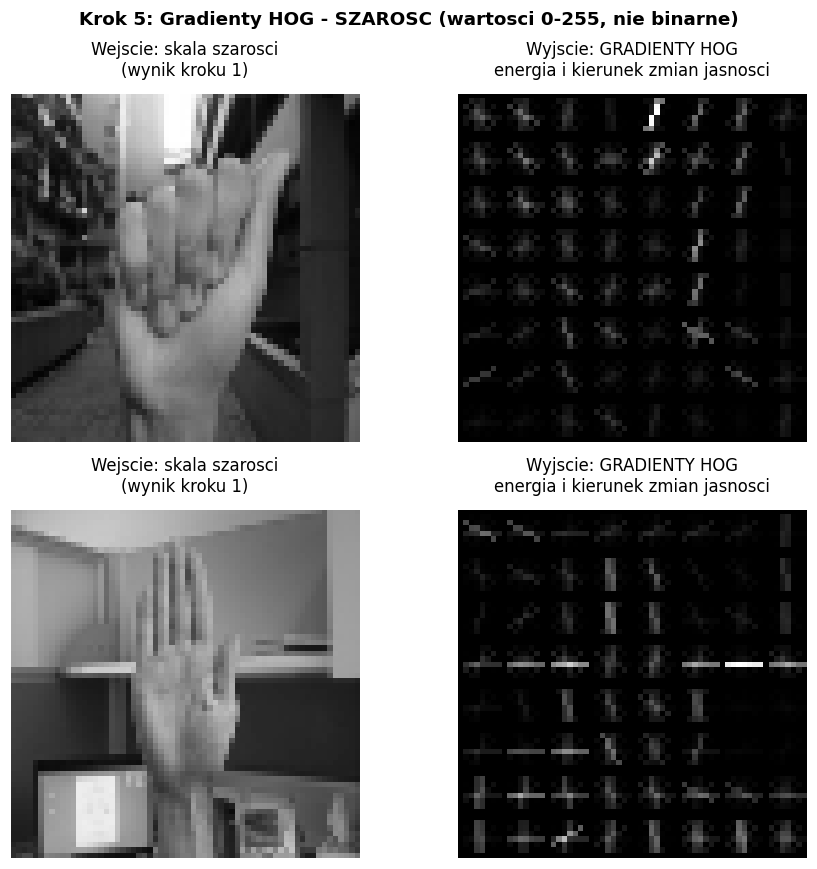

## Krok 6 - F2 = Maska skóry AND Saliencja

**Dlaczego?** Maska skóry wykrywa kolor - może się mylić w tle. Saliencja wykrywa kontrast wizualny - może reagować na inne wyróżniające się obiekty w kadrze (jasna lampa, odzież w kontrastowym kolorze). Żadna z nich z osobna nie jest wystarczająco niezawodna.

AND wymaga spełnienia **obu warunków jednocześnie**. Cokolwiek ma kolor skóry, ale nie wyróżnia się wizualnie (np. ściana z podobnym odcieniem) - wypada. Cokolwiek się wyróżnia wizualnie, ale nie ma koloru skóry - wypada. Zostają tylko te piksele, które spełniają oba kryteria niezależnie od siebie, co znacząco redukuje fałszywe detekcje.

**Jak działa?** Bitowy AND: każdy bit wyjściowy = 1 tylko gdy odpowiadające bity obu operandów = 1. Ponieważ maska skóry jest binarna (0 lub 255 = 11111111): tam gdzie maska skóry = 0, wynik = 0; tam gdzie maska skóry = 255, wynik = wartość saliencji.

**Wejście:** maska skóry (binarna: 0 lub 255) i mapa saliencji (szarość: 0–255)

**Wyjście:** 64×64, 1 kanał, uint8, zakres **0–255**

- Jasny = obszar skóry potwierdzony przez saliencję
- Ciemny = poza skórą lub obszar niewyróżniający się

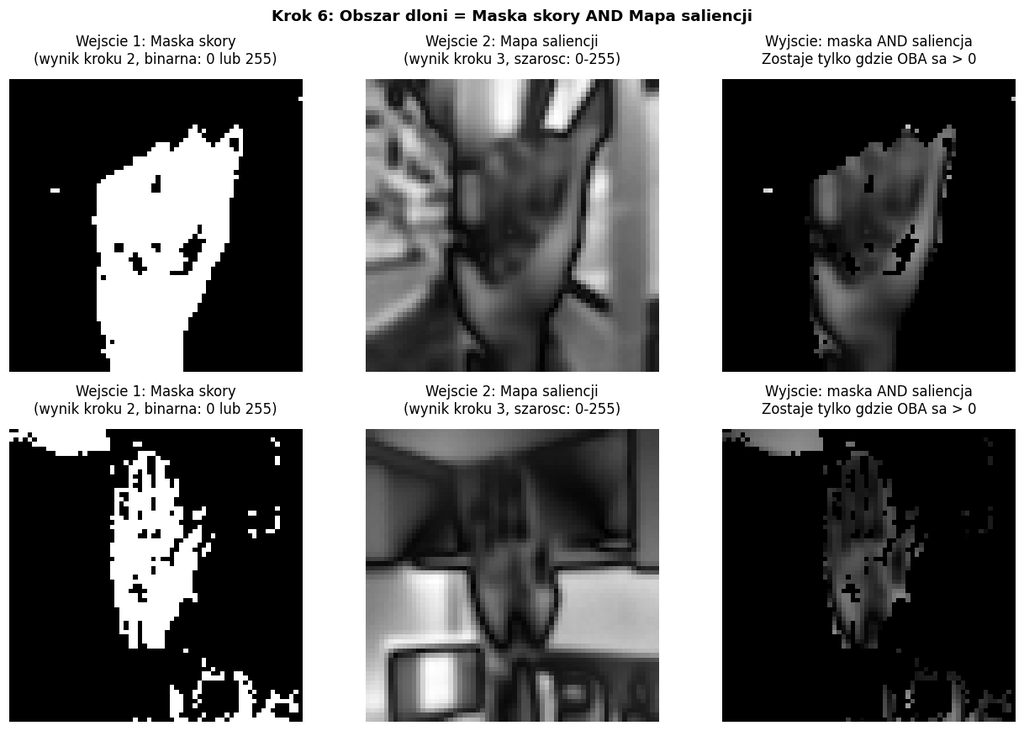

## Krok 7 - F3 = Canny OR HOG

**Dlaczego?** Canny i HOG to dwa komplementarne detektory struktury obrazu. Canny jest precyzyjny - daje cienkie, jednopiksele krawędzie na konturze palców. HOG jest szerszy - wykrywa gradienty też wewnątrz dłoni (linie stawów, zmiany faktury skóry) i zachowuje informację o kierunku.

OR łączy je bez utraty czegokolwiek. Użycie AND tutaj byłoby błędem - wymagałoby żeby oba detektory zgadzały się co do każdego piksela, a ponieważ Canny daje cienkie linie a HOG grubsze obszary, ich AND byłby prawie pusty. OR daje pełny obraz struktury: tam gdzie Canny widzi krawędź, tam F3=255; tam gdzie tylko HOG widzi gradient, tam F3=wartość HOG.

**Jak działa?** Bitowy OR: każdy bit wyjściowy = 1 gdy przynajmniej jeden z wejściowych bitów = 1. Ponieważ Canny jest binarny (0 lub 255=11111111): tam gdzie Canny=255, wynik=255; tam gdzie Canny=0, wynik=wartość HOG.

**Wejście:** Canny (binarna: 0 lub 255) i HOG (szarość: 0–255)

**Wyjście:** 64×64, 1 kanał, uint8, zakres **0–255**

- 255 = krawędź wykryta przez Canny
- wartość HOG = gradient bez krawędzi Canny
- 0 = brak krawędzi i brak gradientu

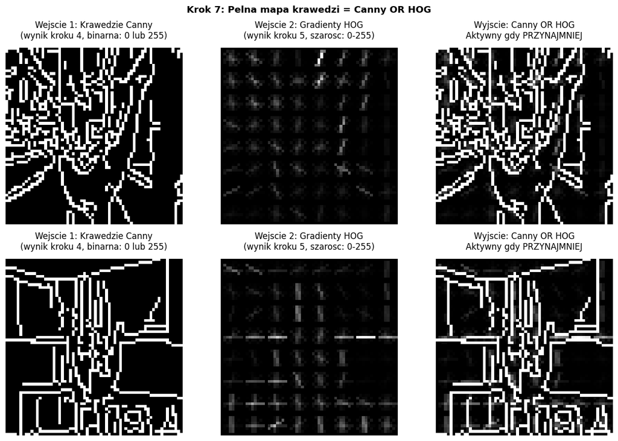

## Krok 8 - F4 = (F2 AND F3) XOR Maska skóry

**Dlaczego?** Potrzebujemy mapy opisującej bryłę dłoni - nie jej kontury (to F3), nie sam obszar koloru skóry (to F2), ale kształt wypełnienia, czyli jak wygląda wnętrze dłoni. Wnętrze różni się między gestami: zamknięta pięść ma duże jednolite wnętrze, rozłożona dłoń ma wąskie wnętrza między palcami.

**Jak działa?** Dwa etapy:

**Etap A - pośredni = F2 AND F3:** Szukamy pikseli, które są jednocześnie w obszarze dłoni (F2 > 0) i na krawędzi lub gradiencie (F3 > 0). To krawędzie leżące wewnątrz obszaru skóry.

**Etap B - F4 = pośredni XOR skin:** XOR daje 1 gdy bity są różne. Ponieważ skin jest binarna (0 lub 255=11111111): poza skórą XOR z 0 nie zmienia nic; wewnątrz skóry XOR z 255 odwraca wszystkie bity. Piksele z silnymi krawędziami (wysoki pośredni ≈ 255) po odwróceniu dają niski F4. Piksele bez krawędzi (pośredni ≈ 0) po odwróceniu dają wysoki F4.

Wynik: F4 jest jasny w środku dłoni (brak krawędzi), ciemny na konturach palców (krawędzie).

**Wejście:** F2 (0–255), F3 (0–255), F_SC (0 lub 255)

**Wyjście:** 64×64, 1 kanał, uint8, zakres **0–255**

- Jasny = wnętrze dłoni (skóra bez krawędzi)
- Ciemny = kontury palców lub obszar poza dłonią

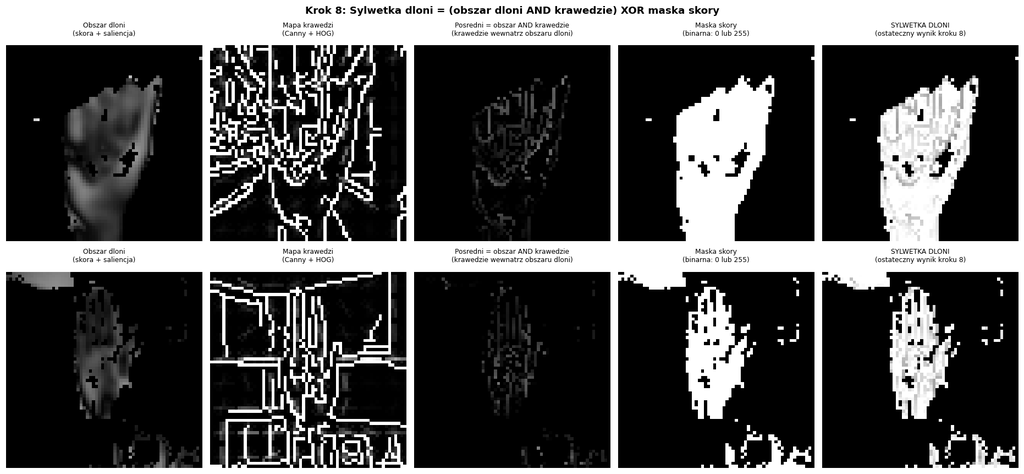

## Krok 9 - Złożenie F2, F3, F4 → wejście SVM

**Dlaczego trzy mapy, a nie jedna?** Każda mapa opisuje inny aspekt dłoni:

- **F2** mówi *gdzie jest dłoń* (obszar skóry potwierdzony saliencją)
- **F3** mówi *jak wygląda kontur* (krawędzie i gradienty)
- **F4** mówi *jak wygląda wnętrze* (bryła dłoni bez konturów)

**Jak wygląda wejście do SVM?** Trzy mapy 64×64 układane są jako trzy kanały tensora 64×64×3 (jak obraz RGB, ale to nie są kanały kolorów - to trzy różne mapy cech). Tensor jest spłaszczany do jednowymiarowego wektora 12 288 liczb. SVM widzi tylko ten wektor - nie wie, że to były obrazy.

**Jak działa?** np.stack([F2, F3, F4], axis=-1) tworzy tensor 64×64×3. .flatten() zamienia go na wektor 12 288 elementów.

**Wejście:** F2, F3, F4 - każda 64×64, uint8, 0–255

**Wyjście:** wektor **12 288 wartości** (64 × 64 × 3 = 12 288)

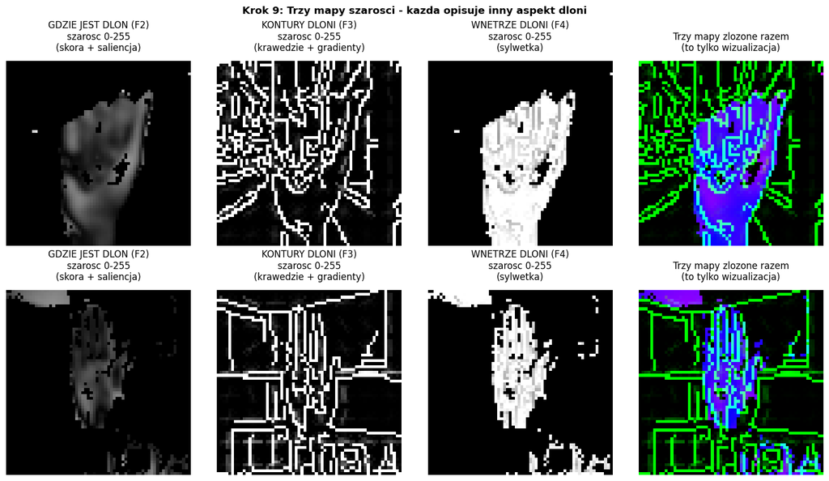

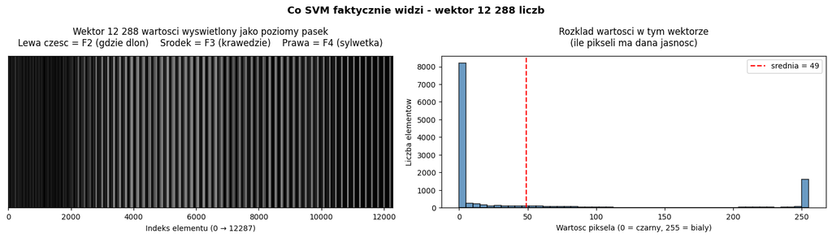

## Wszystkie etapy - widok zbiorczy dla obu obrazów

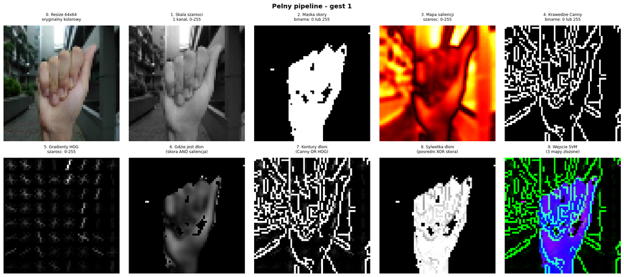

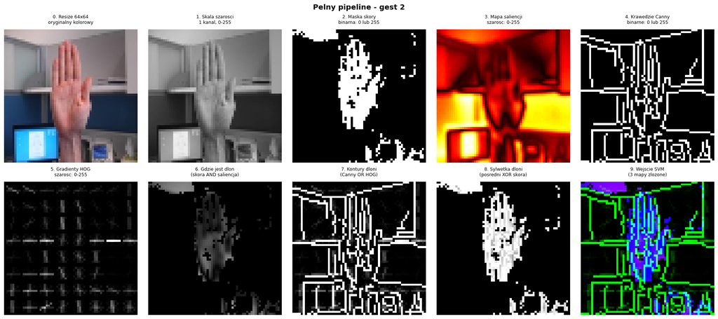

# Przykład 8×8 - operacje bitowe na rzeczywistych wartościach

Poniżej pipeline odtworzony na planszy **8×8 pikseli** z wartościami odpowiadającymi rzeczywistym typom danych używanym w kodzie.

### Typy danych map wejściowych

| Mapa | Typ | Zakres wartości | Dlaczego taki format |
| --- | --- | --- | --- |
| **Skala szarości** | szarość | **0–255 z wartościami pośrednimi** | jasność piksela - wejście do Canny i HOG |
| **Maska skóry** | binarna | **tylko 0 lub 255** | cv2.inRange zwraca tylko 0/255 |
| **Mapa saliencji** | szarość | **0–255 z wartościami pośrednimi** | algorytm saliencji zwraca float skalowany do uint8 |
| **Krawędzie Canny** | binarna | **tylko 0 lub 255** | detektor krawędzi zwraca tylko 0/255 |
| **Gradienty HOG** | szarość | **0–255 z wartościami pośrednimi** | energia gradientu normalizowana do zakresu 0–255 |

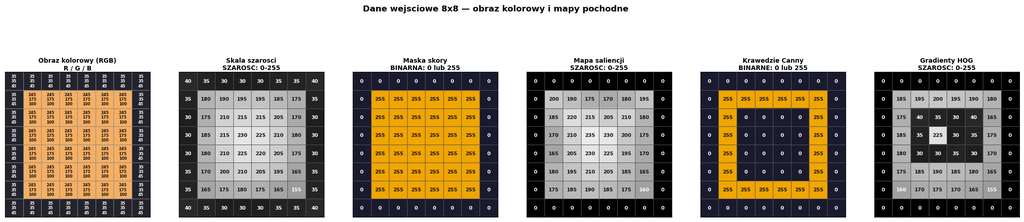

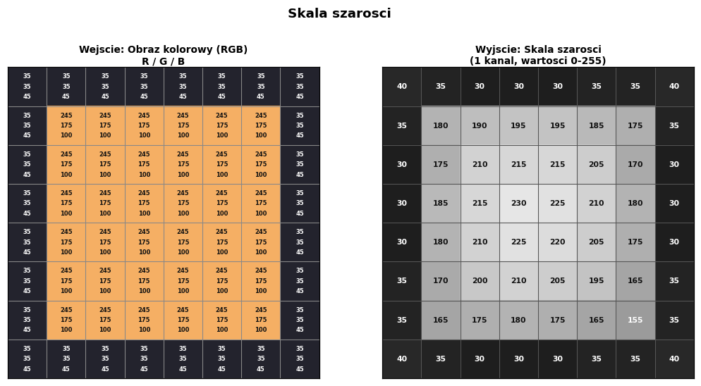

**Wzór:** Y = 0.299·R + 0.587·G + 0.114·B (wagi odzwierciedlają czułość ludzkiego oka - zielony wydaje się najjaśniejszy)

**Tło** RGB=[35,35,45]: Y = 0.299×35 + 0.587×35 + 0.114×45 = 10.5 + 20.5 + 5.1 = **36**

**Dłoń** RGB=[245,175,100]: Y = 0.299×245 + 0.587×175 + 0.114×100 = 73.3 + 102.7 + 11.4 = **187**

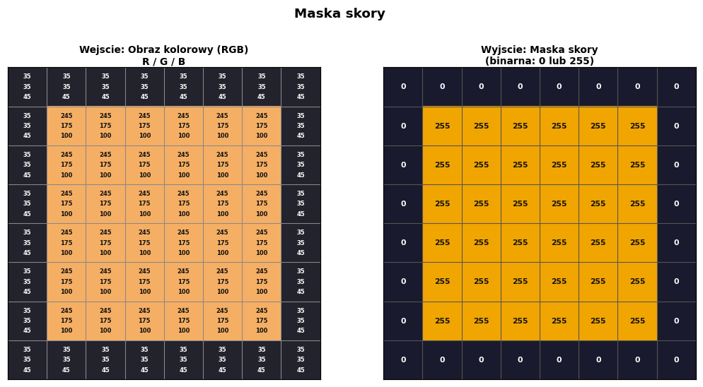

**Tło** BGR=[45,35,35] → HSV: H=120, S=57, V=45 → H=120 **NIE** ∈ [0,17] → maska = **0**

**Dłoń** BGR=[100,175,245] → HSV: H=16, S=151, V=245 → H=16 **TAK** ∈ [0,17], S=151 **TAK** ∈ [15,170] → maska = **255**

**Obliczenie** R=245 jest największy, delta = 245−100 = 145:

```
H° = 60 × (G−B) / delta = 60 × (175−100) / 145 = 31°
H_opencv = 31 / 2 = 16
S = (145 / 245) × 255 = 151
V = 245
```

H=16 mieści się w zakresie skóry [0, 17] - R dominuje, piksel jest ciepły/pomarańczowy.

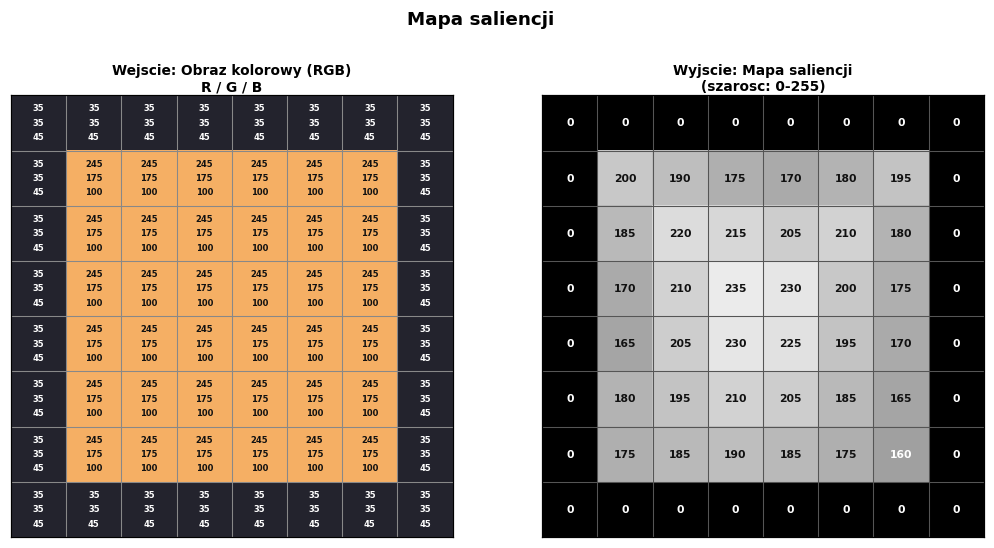

**Tło** rgb=[35,35,45]: otoczony identycznym tłem, lokalny kontrast ≈ 0 → sal = **0**

**Dłoń** rgb=[245,175,100]: wyróżnia się na tle, duży kontrast lokalny → sal ≈ **200**

> Wartość 200 jest syntetyczna - w rzeczywistości `StaticSaliencyFineGrained` działa w przestrzeni częstotliwości (FFT), nie oblicza prostych różnic RGB. Im bardziej piksel wyróżnia się na tle otoczenia, tym wyższa wartość saliencji.

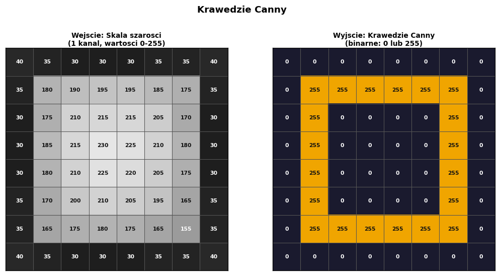

**Piksel [0,1]=35 → [1,1]=180**: gradient = |180−35| = **145** → strefa histereza (50–150): TAK, bo sąsiaduje z pikselami o gradiencie >150 → canny = **255**

**Piksel [2,2]=210 → [2,3]=215**: gradient = |215−210| = **5** < próg dolny 50 → zawsze odrzucony → canny = **0**

> Canny używa dwóch progów: gradient **>150** = pewna krawędź; gradient **50–150** = krawędź tylko jeśli sąsiaduje z pewną krawędzią (histereza); gradient **<50** = odrzucony.

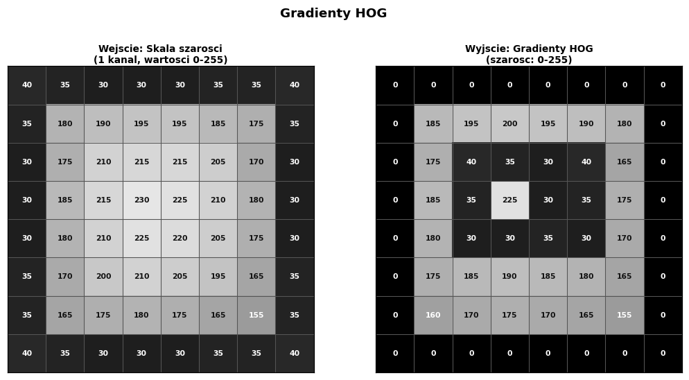

**Piksel [1,1]**: gradient poziomy = |gray[1,2]−gray[1,0]| = |190−35| = **155** (silna zmiana) → po agregacji w histogramie i normalizacji blokowej HOG → hog = **185**

**Piksel [2,2]**: gradient poziomy = |gray[2,3]−gray[2,1]| = |215−175| = **40** (słaba zmiana) → po agregacji i normalizacji → hog = **40**

> Wartość HOG ≠ surowy gradient - jest wynikiem histogramu orientacji w komórce 8×8 i normalizacji L2 w bloku 2×2 komórek.

### F2 = Maska skóry AND Mapa saliencji

Maska skóry jest binarna - zawiera tylko 0 i 255 (binarnie: 00000000 i 11111111). Operacja AND z taką wartością ma prostą właściwość:

- **0 AND cokolwiek = 0** - zero ma wszystkie bity równe 0, więc wynik zawsze 0
- **255 AND cokolwiek = to cokolwiek** - 255 ma wszystkie bity równe 1, więc niczego nie zmienia

Efekt: F2 jest identyczny z mapą saliencji wewnątrz obszaru skóry, a zero poza nim. Wartości pośrednie saliencji (170, 200, 235...) zostają bez zmian.

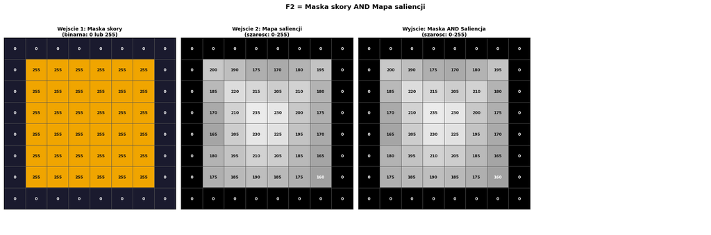

### F3 = Canny OR HOG

Canny jest binarna - zawiera tylko 0 i 255. Operacja OR z taką wartością:

- **255 OR cokolwiek = 255** - 255 ma wszystkie bity równe 1, więc wynik zawsze 255
- **0 OR cokolwiek = to cokolwiek** - zero nie zmienia żadnego bitu

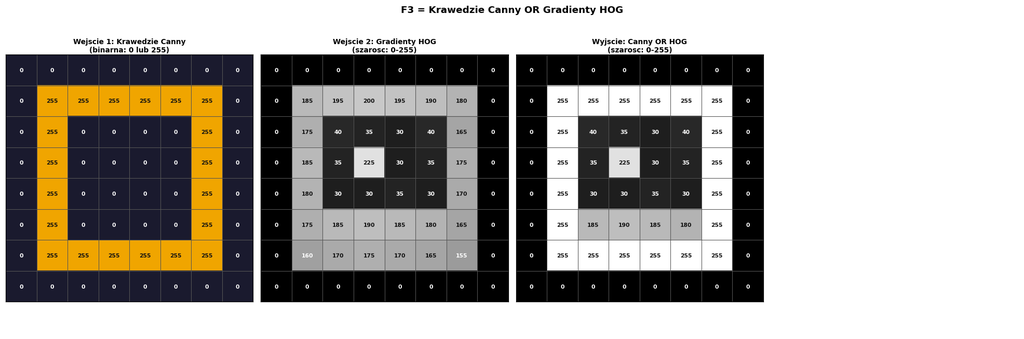

### F4 = (F2 AND F3) XOR Maska skóry - dwa etapy

**Etap A - pośredni = F2 AND F3**

Tu oba operandy mają wartości 0–255 - nie ma skrótu jak poprzednio. AND działa bit po bicie między dwiema wartościami pośrednimi. Wynik zależy od nakładania się bitów obu operandów.

**Etap B - F4 = pośredni XOR Maska skóry**

XOR: bit wynikowy = 1 gdy bity wejściowe są różne. Ponieważ maska skóry jest binarna:

- **x XOR 0 = x** - poza skórą: wartość nie zmienia się
- **x XOR 255 = NOT(x)** - wewnątrz skóry: wszystkie bity odwrócone

Konsekwencja: im wyższy był pośredni (silna krawędź), tym niższy F4. Piksele bez krawędzi (pośredni ≈ 0) dają po XOR z 255 wysoką wartość F4 ≈ 255.

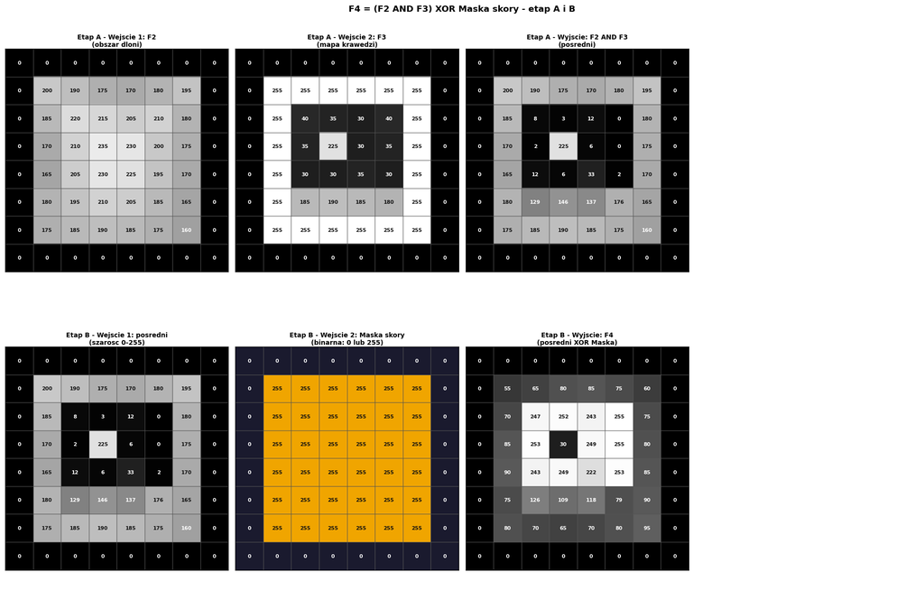

### Podsumowanie przykładu 8×8 - wszystkie mapy

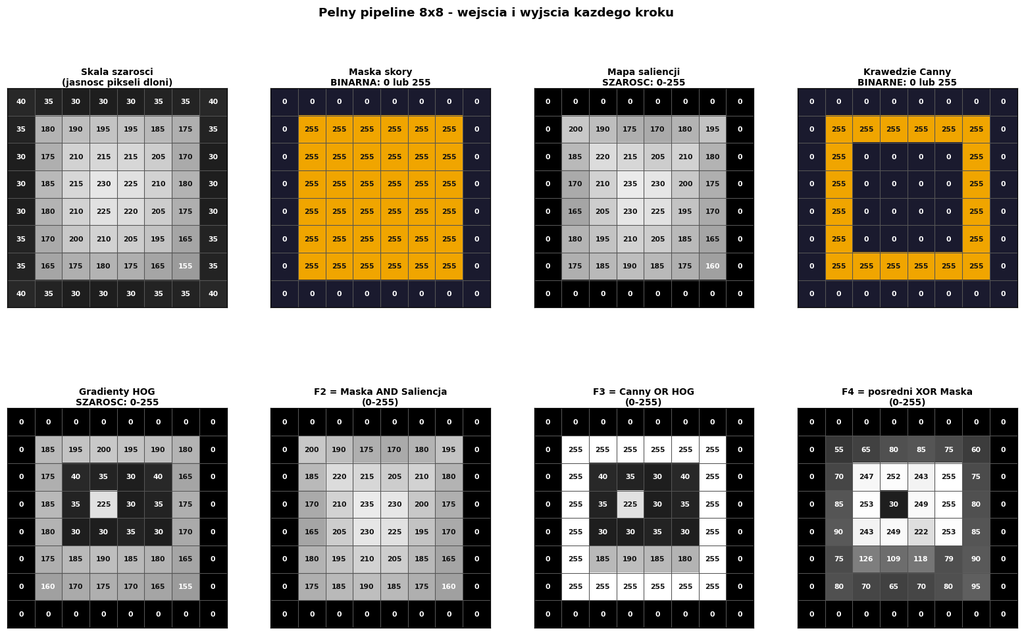

## Tabela podsumowująca - typy danych na każdym etapie

| Krok | Operacja | Wejście | Format wyjścia |
| --- | --- | --- | --- |
| 0 | Resize 64×64 | dowolny rozmiar BGR | uint8, 0–255, 3 kanały |
| 1 | BGR → skala szarości | 64×64 BGR | uint8, **0–255**, 1 kanał |
| 2 | BGR → HSV + progowanie | 64×64 BGR | uint8, **tylko 0 lub 255**, 1 kanał |
| 3 | Saliencja StaticSaliencyFineGrained | 64×64 BGR | uint8, **0–255 z wartościami pośrednimi**, 1 kanał |
| 4 | Canny(gray, 50, 150) | F1 szarość | uint8, **tylko 0 lub 255**, 1 kanał |
| 5 | HOG + wizualizacja | F1 szarość | uint8, **0–255 z wartościami pośrednimi**, 1 kanał |
| 6 | bitwise_and(F_SC, F_S) | F_SC + F_S | uint8, 0–255, 1 kanał |
| 7 | bitwise_or(Canny, HOG) | Canny + HOG | uint8, 0–255, 1 kanał |
| 8 | bitwise_xor(F2∧F3, F_SC) | F2+F3+F_SC | uint8, 0–255, 1 kanał |
| 9 | np.stack([F2,F3,F4]) + flatten() | F2, F3, F4 | wektor **12 288 wartości** → SVM |